# Iris Species Classification - Logistic Regression Step-by-Step Training

Data Science Training

November 10, 2025

# Introduction

This comprehensive training document demonstrates a step-by-step approach to building multinomial logistic regression models for classifying Iris flower species. We will progress from data exploration to model evaluation, covering feature analysis, multiclass classification techniques, and comprehensive model validation.

# Step 1: Data Loading and Initial Exploration

## Load and Examine Dataset

```r
# Load the Iris dataset
data(iris)
cat("Dataset Dimensions:", dim(iris), "\n\n")
```

```
## Dataset Dimensions: 150 5
```

```r
cat("Species Distribution:\n")
```

```
## Species Distribution:
```

```r
print(table(iris$Species))
```

```
##
##     setosa versicolor  virginica
##         50         50         50
```

```r
cat("\nProportions:\n")
```

```
##
## Proportions:
```

```r
print(prop.table(table(iris$Species)))
```

```
##
##     setosa versicolor  virginica
##  0.3333333  0.3333333  0.3333333
```

```r
# Display dataset structure
cat("\nDataset Structure:\n")
```

```
##
## Dataset Structure:
```

```r
str(iris)
```

```
## 'data.frame':    150 obs. of  5 variables:
##  $ Sepal.Length: num  5.1 4.9 4.7 4.6 5 5.4 4.6 5 4.4 4.9 ...
##  $ Sepal.Width : num  3.5 3 3.2 3.1 3.6 3.9 3.4 3.4 2.9 3.1 ...
##  $ Petal.Length: num  1.4 1.4 1.3 1.5 1.4 1.7 1.4 1.5 1.4 1.5 ...
##  $ Petal.Width : num  0.2 0.2 0.2 0.2 0.2 0.4 0.3 0.2 0.2 0.1 ...
##  $ Species     : Factor w/ 3 levels "setosa","versicolor",..: 1 1 1 1 1 1 1 1 1 1 ...
```

```r
# First few observations
cat("\nFirst 6 observations:\n")
```

```
##
## First 6 observations:
```

```r
head(iris) %>% kable() %>% kable_styling(bootstrap_options = "striped")
```

| Sepal.Length | Sepal.Width | Petal.Length | Petal.Width | Species |
| --- | --- | --- | --- | --- |
| 5.1 | 3.5 | 1.4 | 0.2 | setosa |
| 4.9 | 3.0 | 1.4 | 0.2 | setosa |
| 4.7 | 3.2 | 1.3 | 0.2 | setosa |
| 4.6 | 3.1 | 1.5 | 0.2 | setosa |
| 5.0 | 3.6 | 1.4 | 0.2 | setosa |
| 5.4 | 3.9 | 1.7 | 0.4 | setosa |

**Inference:** The Iris dataset contains 150 observations evenly distributed across three species (Setosa, Versicolor, Virginica), with 4 numerical features describing sepal and petal dimensions. This balanced distribution makes it ideal for classification modeling.

# Step 2: Comprehensive Data Exploration

## Step 2.1: Pairwise Scatter Matrix with Correlations

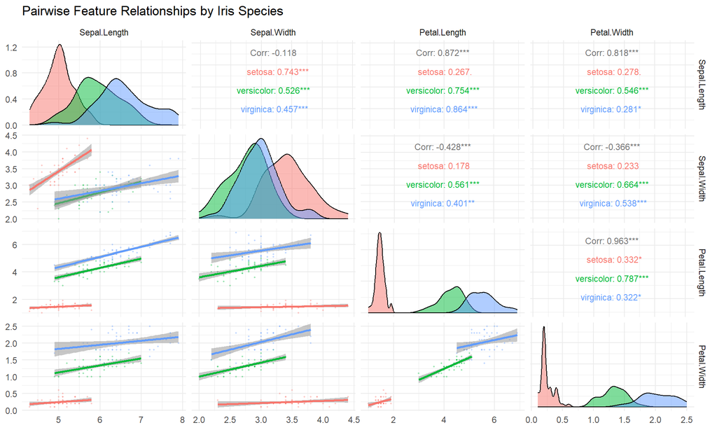

```r
# Create comprehensive pairwise scatter plot matrix
ggpairs(iris, columns = 1:4,
        mapping = ggplot2::aes(color = Species, alpha = 0.6),
        upper = list(continuous = wrap('cor', size = 3)),
        lower = list(continuous = wrap('smooth', alpha = 0.3, size = 0.4)),
        diag = list(continuous = wrap('densityDiag', alpha = 0.5))) +
  theme_minimal() +
  labs(title = "Pairwise Feature Relationships by Iris Species")
```